# This is MBG404 Midterm Template

2023-04-25

1. [TCGA Paper on Human Melanoma](https://pubmed.ncbi.nlm.nih.gov/26091043/)
- Investigation of genomic changes in cutaneous melanoma based on DNA, RNA and protein analyzes of 333 melanoma (primary or metastatic) samples from 331 patients.

# 1 Graphical Abstract of The Paper

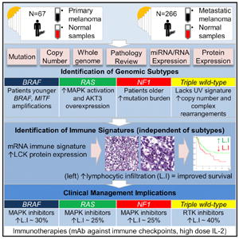

# 2 Download the SKCM Data

```r
skcm_rna_data <- readRDS("skcm_rna_data.rds")

skcm_mir_data <- readRDS("skcm_mir_data.rds")

skcm_meta_data <- readRDS("skcm_meta_data.rds")
```

## 2.1 .a Dimensions of these three datas

```r
dim(skcm_meta_data)
```

```
## [1] 473 231
```

```r
dim(skcm_mir_data)
```

```
## [1] 473 628
```

```r
dim(skcm_rna_data)
```

```
## [1] 473 115
```

## 2.2 .b Containing of each data file. The *“meta.barcode”* column is common to all.

```r
skcm_meta_data[1:5, 1:5]
```

```
##                   meta.barcode meta.patient meta.shortLetterCode
## 1 TCGA-3N-A9WB-06A-11R-A38C-07 TCGA-3N-A9WB                   TM
## 2 TCGA-3N-A9WC-06A-11R-A38C-07 TCGA-3N-A9WC                   TM
## 3 TCGA-3N-A9WD-06A-11R-A38C-07 TCGA-3N-A9WD                   TM
## 4 TCGA-BF-A1PU-01A-11R-A18S-07 TCGA-BF-A1PU                   TP
## 5 TCGA-BF-A1PV-01A-11R-A18U-07 TCGA-BF-A1PV                   TP
##       meta.definition meta.sample_submitter_id
## 1          Metastatic         TCGA-3N-A9WB-06A
## 2          Metastatic         TCGA-3N-A9WC-06A
## 3          Metastatic         TCGA-3N-A9WD-06A
## 4 Primary solid Tumor         TCGA-BF-A1PU-01A
## 5 Primary solid Tumor         TCGA-BF-A1PV-01A
```

```r
skcm_mir_data[1:5, 1:5]
```

```
##                   meta.barcode hsa.let.7a.5p hsa.let.7b.5p hsa.let.7c.5p
## 1 TCGA-3N-A9WB-06A-11R-A38C-07            NA            NA            NA
## 2 TCGA-3N-A9WC-06A-11R-A38C-07            NA            NA            NA
## 3 TCGA-3N-A9WD-06A-11R-A38C-07      4.995904      4.523672      4.002199
## 4 TCGA-BF-A1PU-01A-11R-A18S-07      4.974219      4.731226      3.198780
## 5 TCGA-BF-A1PV-01A-11R-A18U-07      4.759249      4.174712      3.212700
##   hsa.let.7d.5p
## 1            NA
## 2            NA
## 3      2.870594
## 4      2.600473
## 5      2.435391
```

```r
skcm_rna_data[1:5, 1:5]
```

```
##                   meta.barcode      CD8A       CD4      CD3E       IFNG
## 1 TCGA-3N-A9WB-06A-11R-A38C-07 0.1381094 0.8127527 0.1442917 0.00000000
## 2 TCGA-3N-A9WC-06A-11R-A38C-07 2.0444590 2.0409068 1.8400455 0.85132166
## 3 TCGA-3N-A9WD-06A-11R-A38C-07 1.4000004 1.6974816 1.5316792 0.15937525
## 4 TCGA-BF-A1PU-01A-11R-A18S-07 0.1065013 0.9809766 0.2119108 0.00000000
## 5 TCGA-BF-A1PV-01A-11R-A18U-07 0.1924963 1.0528621 0.4618483 0.02028116
```

## 2.3 .c miRNA and RNA files are log-normalized.

- When performing multivariate analyzes, we want each variable to contribute equally to the analysis. However, the original skcm_rna data is very skewed and quite different from each other. Therefore, the “skcm_rna_data” values here are individually log values scaled. Thus, as seen in boxplots, the graph obtained from log-normalized data has a small and standard scale. In addition, since the amount of difference between the variables was scaled, the ratio of each variable to the analysis was equalized.

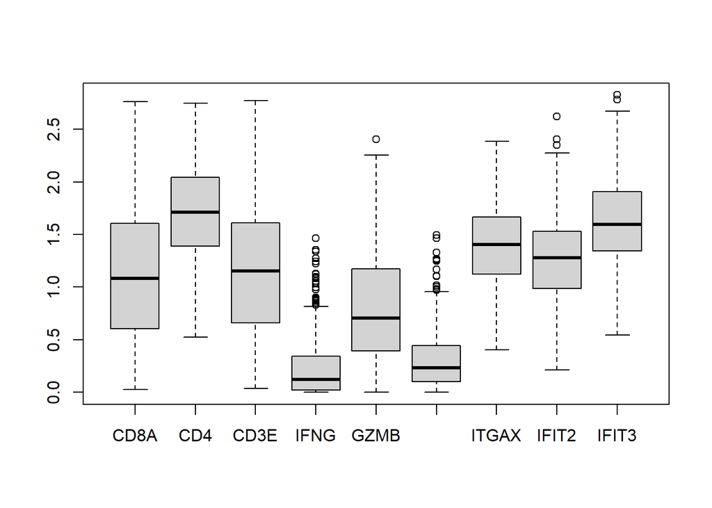

```r
boxplot(skcm_rna_data[,2:10])
```

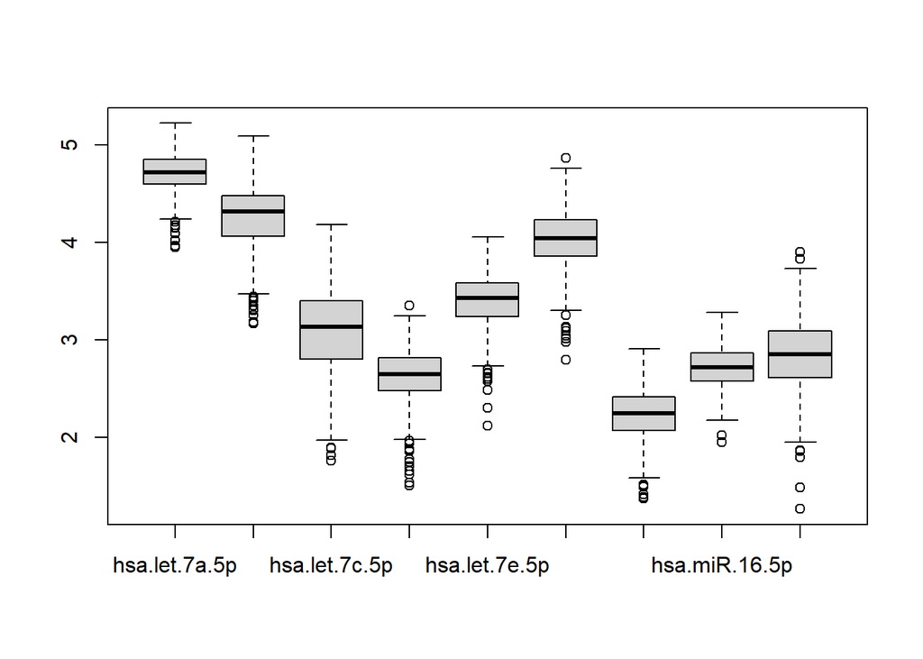

```r
boxplot(skcm_mir_data[,2:10])
```

## 2.4 .d NA presence check in RNA and miRNA data

```r
any(is.na(skcm_rna_data)) # This function result is "FALSE" that means there is no NA in the "skcm_rna_data".
```

```
## [1] FALSE
```

```r
any(is.na(skcm_mir_data)) # This function result is "TRUE" that means there is NA in the "skcm_mir_data".
```

```
## [1] TRUE
```

```r
sum(is.na(skcm_mir_data)) # There are 14421 NAs in the "skcm_mir_data".
```

```
## [1] 14421
```

## 2.5 .e Function that checks whether there is duplicate data in the “meta_patient” variable of skcm_meta_data and returns a number if any

```r
anyDuplicated(skcm_meta_data$meta.patient) # Yes, this column has  duplication. The first duplication is the 37th row.
```

```
## [1] 37
```

```r
sum(duplicated(skcm_meta_data$meta.patient)) # Duplicated data belong to 4 different observations.
```

```
## [1] 4
```

```r
anyDuplicated(skcm_meta_data$meta.barcode) # There are no duplications in the meta.barcode column, so each example is different.
```

```
## [1] 0
```

```r
dup_meta_patient <- duplicated(skcm_meta_data$meta.patient) | duplicated(skcm_meta_data$meta.patient, fromLast = TRUE)  # dup_meta_patient shows that the all duplicated meta.patient data.

# Looking the duplicated meta.patient data.
dup_meta <- (skcm_meta_data[dup_meta_patient, ])

dup_meta[1:8, 1:4]
```

```
##                     meta.barcode meta.patient meta.shortLetterCode
## 36  TCGA-D3-A1QA-06A-11R-A18T-07 TCGA-D3-A1QA                   TM
## 37  TCGA-D3-A1QA-07A-11R-A37K-07 TCGA-D3-A1QA                  TAM
## 315 TCGA-ER-A19T-01A-11R-A18T-07 TCGA-ER-A19T                   TP
## 316 TCGA-ER-A19T-06A-11R-A18U-07 TCGA-ER-A19T                   TM
## 323 TCGA-ER-A2NF-01A-11R-A18T-07 TCGA-ER-A2NF                   TP
## 324 TCGA-ER-A2NF-06A-11R-A18T-07 TCGA-ER-A2NF                   TM
## 412 TCGA-GN-A4U8-11A-11R-A32P-07 TCGA-GN-A4U8                   NT
## 413 TCGA-GN-A4U8-06A-11R-A32P-07 TCGA-GN-A4U8                   TM
##           meta.definition
## 36             Metastatic
## 37  Additional Metastatic
## 315   Primary solid Tumor
## 316            Metastatic
## 323   Primary solid Tumor
## 324            Metastatic
## 412   Solid Tissue Normal
## 413            Metastatic
```

```r
# However, in the meta.patient column, 4 observations are duplicated. This is because of different tissue samples taken from the same patient (such as one primary solid tumor and the other metastatic). That is, there is no similarity in the entire row..
```

# 3 Merging these three data frames

## 3.1 .a We must merge these dataframes with the “meta.barcode” variable.

```r
library(tidyverse)
merged_rna_mir <- left_join(skcm_rna_data, skcm_mir_data, by = "meta.barcode")

merged_df <- left_join(merged_rna_mir, skcm_meta_data, by = "meta.barcode")
```

## 3.2 .b Dimensions of “merged_df”

```r
dim(merged_df)
```

```
## [1] 473 972
```

## 3.3 .c Determining any duplications or data loss

```r
anyDuplicated(merged_df) #The output is taken as 0, so there is no duplication.
```

```
## [1] 0
```

```r
# With merged_df, the observation count of each data is exactly the same. Therefore, there is no data loss on the basis of observation.
dim(skcm_meta_data)
```

```
## [1] 473 231
```

```r
dim(skcm_rna_data)
```

```
## [1] 473 115
```

```r
dim(skcm_meta_data)
```

```
## [1] 473 231
```

```r
# While the total number of variables is 974, it is seen as 972 in "merged_df". That is, there are 2 missing data on the basis of variables.

sum(dim(skcm_meta_data[0, ]), dim(skcm_mir_data[0, ]), dim(skcm_rna_data[0, ]))
```

```
## [1] 974
```

# 4 Calculating some grouped statistics using dplyr

## 4.1 .a Average expression of `CD8A` in primary and metastatic samples

```r
CD8A <- merged_df %>%
  group_by(meta.definition) %>%
  summarize(average.CD8A = mean(CD8A, na.rm = TRUE)) %>%
  filter(meta.definition %in% c("Primary solid Tumor", "Metastatic"))

CD8A[]
```

```
## # A tibble: 2 × 2
##   meta.definition     average.CD8A
##   <fct>                      <dbl>
## 1 Metastatic                 1.18
## 2 Primary solid Tumor        0.868
```

## 4.2 .b Average expression of `hsa.miR.155.5p` in males and females

```r
hsa.miR.155.5p <- merged_df %>%
  group_by(meta.gender) %>%
  summarize(average_hsa.miR.155.5p = mean(hsa.miR.155.5p, na.rm = TRUE)) %>%
  filter(meta.gender %in% c("female", "male"))

hsa.miR.155.5p[]
```

```
## # A tibble: 2 × 2
##   meta.gender average_hsa.miR.155.5p
##   <fct>                        <dbl>
## 1 female                        2.93
## 2 male                          2.89
```

# 5 Creating a new data frame `df1` that contains patients who passed away

```r
df1 <- merged_df %>% filter(meta.vital_status == 1)
```

## 5.1 .a Creating a scatter plot between `meta.days_to_event` and `IFNG`

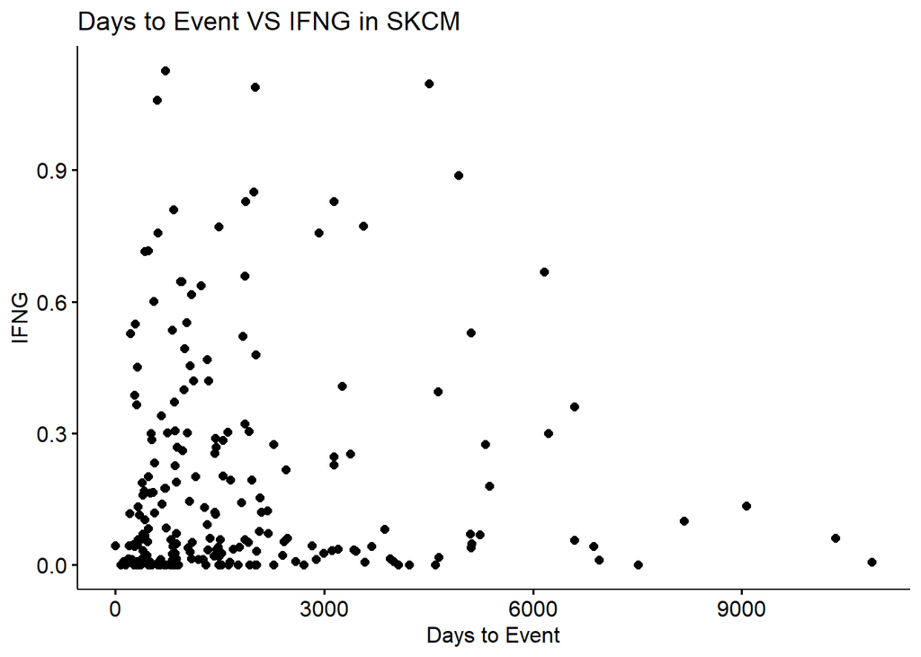

```r
library(ggpubr)

df1 %>%
    ggscatter(
      x = "meta.days_to_event",
      y = "IFNG",
      xlab = "Days to Event",
      title = "Days to Event VS IFNG in SKCM")
```

## 5.2 .b Adding a regression line to scatter plot

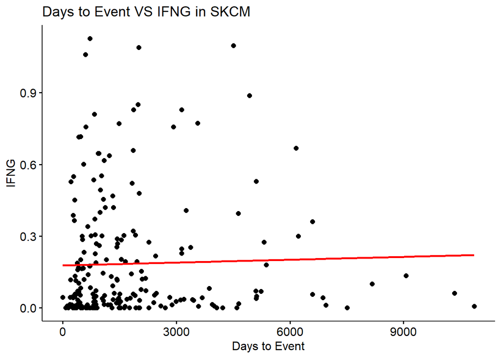

```r
df1 %>%
    ggscatter(
      x = "meta.days_to_event",
      y = "IFNG",
      xlab = "Days to Event",
      title = "Days to Event VS IFNG in SKCM",
      add = "reg.line",
      add.params = list(color = "red"))
```

## 5.3 .c Showing linear regression parameters on the graph

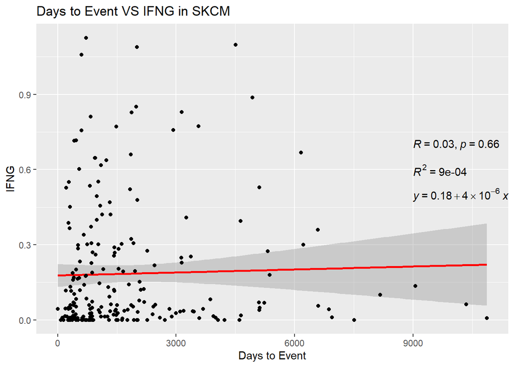

```r
library(ggplot2)

ggplot(data = df1, aes(x = meta.days_to_event, y = IFNG)) +
        labs(title = "Days to Event VS IFNG in SKCM", x = "Days to Event")+
        geom_smooth(method="lm", color = "red") +
        geom_point() +
        stat_regline_equation(label.x = 9000, label.y = 0.5) +
        stat_cor(aes(label=..rr.label..), label.x = 9000, label.y = 0.6) +
        stat_cor(label.x = 9000, label.y = 0.7)
```

## 5.4 .d This scatter plot describes the relationship between time to death and IFNG in deceased patients, and the red regression line gives the correlation of the graph.

# 6 Creating a new data frame `df2` that contains “CD8A”, “ADGRE1”, “ITGAX”, “meta.t.cells.cd8”, “meta.barcode”, “meta.gender”, “meta.sample_type”.

```r
df2 <- merged_df %>%
  select("CD8A", "ADGRE1", "ITGAX", "meta.t.cells.cd8", "meta.barcode", "meta.gender", "meta.sample_type")

df2[1:3, 1:3]
```

```
##        CD8A      ADGRE1     ITGAX
## 1 0.1381094 0.008474397 0.7335054
## 2 2.0444590 0.432443399 1.4059094
## 3 1.4000004 0.268850824 1.8822586
```

## 6.1 .a Reshaping the data frame to long form.

```r
df2.1 <- df2 %>% pivot_longer(cols = c("CD8A", "ADGRE1", "ITGAX"), names_to = "gene", values_to = "expression")

df2.1[1:3, 1:3]
```

```
## # A tibble: 3 × 3
##   meta.t.cells.cd8 meta.barcode                 meta.gender
##              <dbl> <fct>                        <fct>
## 1           0.0402 TCGA-3N-A9WB-06A-11R-A38C-07 male
## 2           0.0402 TCGA-3N-A9WB-06A-11R-A38C-07 male
## 3           0.0402 TCGA-3N-A9WB-06A-11R-A38C-07 male
```

## 6.2 .b Creating a scatter plot by placing `meta.t.cells.cd8` on the x-axis and `expression` on the y-axis.

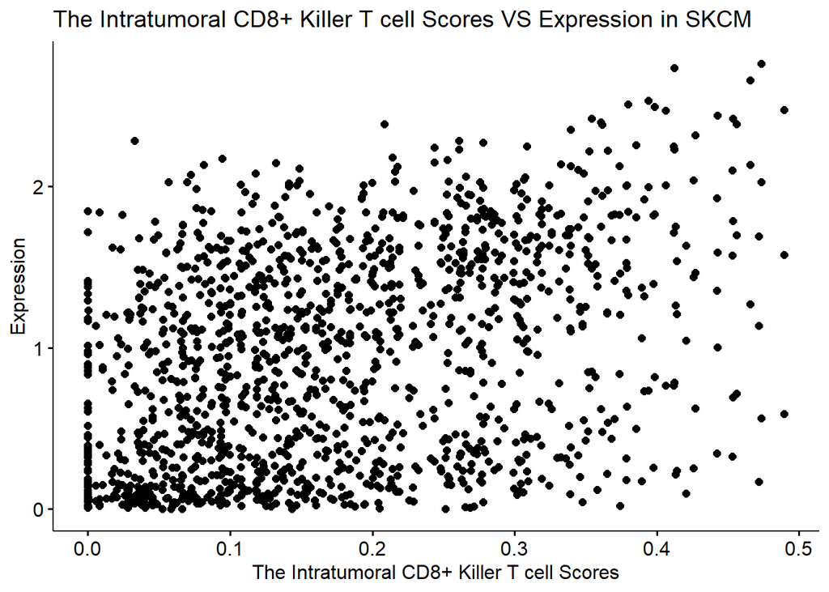

```r
df2.1 %>%
    ggscatter(
      x = "meta.t.cells.cd8",
      y = "expression",
      xlab = "The Intratumoral CD8+ Killer T cell Scores",
      ylab = "Expression",
      title = "The Intratumoral CD8+ Killer T cell Scores VS Expression in SKCM")
```

```r
# I don't think this graph is meaningful because it is important to see what genes are expressed in order to see the relationship between T-cell scores and expression.
```

## 6.3 .c Creating the same scatter plot as in (b), but this time color by `gene`.

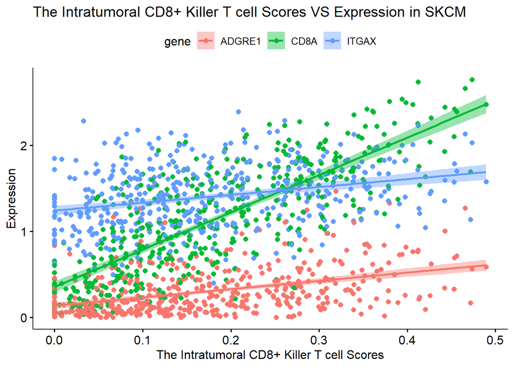

```r
df2.1 %>%
    ggscatter(
      x = "meta.t.cells.cd8",
      y = "expression",
      xlab = "The Intratumoral CD8+ Killer T cell Scores",
      ylab = "Expression",
      title = "The Intratumoral CD8+ Killer T cell Scores VS Expression in SKCM",
      color = "gene",
      add = "reg.line",
      add.params = list(color = "gene", fill = "gene"),
      conf.int = TRUE)
```

```r
# I think this graph is more meaningful than the previous graph because I can see how much of each gene is expressed to see the relationship between T-cell scores and expression. I can also see the distribution of the expression of the genes according to the T-cell score. However, it is difficult to understand the dense parts of the graph where the genes are mixed with each other.
```

## 6.4 .d Creating the same scatter plot as in (c), but this time also add `meta.gender` as a facet.

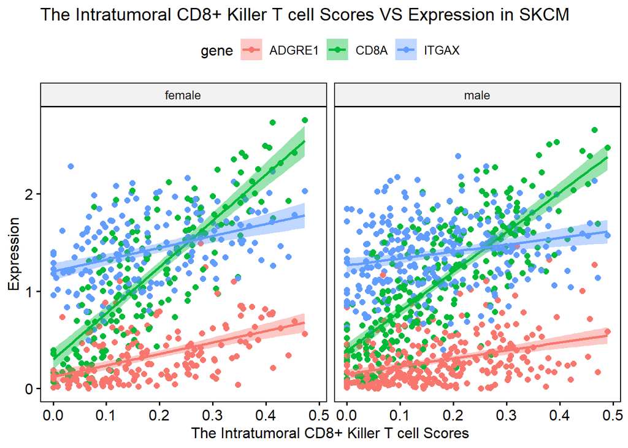

```r
df2.1 %>%
    ggscatter(
      x = "meta.t.cells.cd8",
      y = "expression",
      xlab = "The Intratumoral CD8+ Killer T cell Scores",
      ylab = "Expression",
      title = "The Intratumoral CD8+ Killer T cell Scores VS Expression in SKCM",
      color = "gene",
      add = "reg.line",
      add.params = list(color = "gene", fill = "gene"),
      conf.int = TRUE,
      facet.by = "meta.gender")
```

```r
# I think this graph is more meaningful than the previous graph because I can see how much of each gene is expressed in men and women separately in order to see the relationship between T-cell scores and expression. In addition, I can see the distribution of the expression of genes according to the T-cell score, separately in men and women. However, it is difficult to understand the dense parts of the graph where the genes are mixed with each other.
```

## 6.5 .e

```r
# Looking at the last graph, it is seen that there is a positive correlation between the T cell signature and CD8A. That is, as the T cell signature increases, the amount of CD8A also increases. This is an expected result because the alpha chain (which aids in antigen recognition) on the surface of CD8+ killer T cells is produced by the CD8A gene.
```

## 6.6 .f

```r
# Looking at the last graph, there is a very low positive correlation between T cell signature and expression levels of macrophage and dendritic cell-specific genes compared to CD8A. One of the reasons for the lower positive correlation may be due to the interaction of macrophage and dendritic cells and T cells in the tumor microenvironment. If the expression of macrophages and dendritic cells is less than expected, we can say that there is an interaction of T cells that renders these cells dysfunctional. As a result of negative interaction with each other, the amount of increase in both may be decreased. If the expression of macrophages and dendritic cells is higher than expected, macrophages may produce something such as cytokines that positively affect the function of T cells. Thus, they can increase the immune response against the tumor as a result of their positive interaction with each other, and the number of both can be increased.
```

# 7 Creating scatter plots to show the relationship between hsa-miR-155-5p levels and their targets (“JARID2”, “BACH1”, “SOCS1”, “INPP5D”)

```r
df3 <- merged_df %>%
  select("JARID2", "BACH1", "SOCS1", "INPP5D", "hsa.miR.155.5p")
```

## 7.1 Scatter Plot of hsa-miR-155-5p VS JARID2 in SKCM

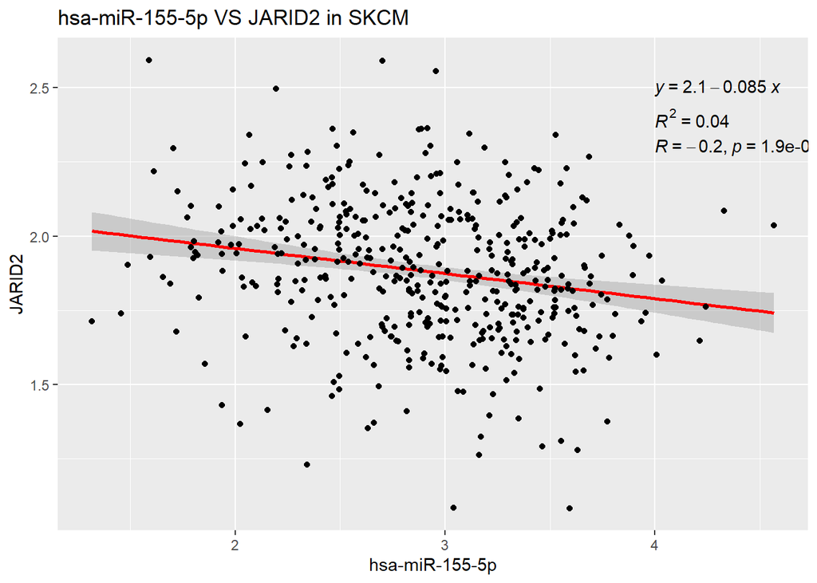

```r
ggplot(data = df3, aes(x = hsa.miR.155.5p, y = JARID2)) +
        labs(title = "hsa-miR-155-5p VS JARID2 in SKCM", x = "hsa-miR-155-5p") +
        geom_smooth(method="lm", color = "red") +
        geom_point() +
  stat_regline_equation(label.x = 4, label.y = 2.5) +
        stat_cor(aes(label=..rr.label..), label.x = 4, label.y = 2.4) +
        stat_cor(label.x = 4, label.y = 2.3)
```

## 7.2 Scatter Plot of hsa-miR-155-5p VS BACH1 in SKCM

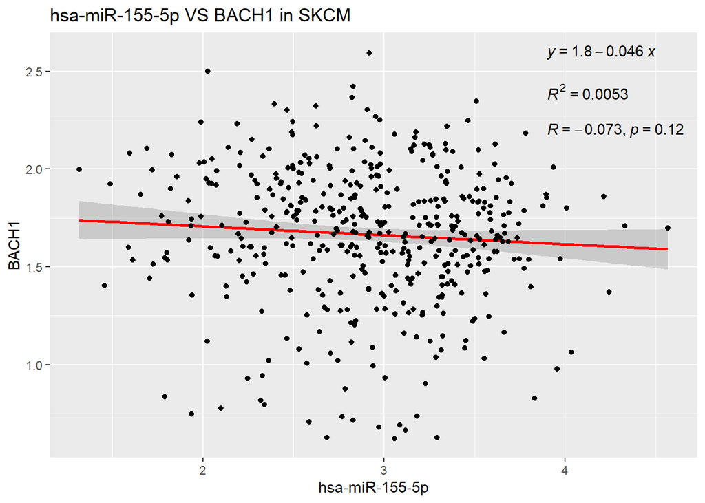

```r
ggplot(data = df3, aes(x = hsa.miR.155.5p, y = BACH1)) +
        labs(title = "hsa-miR-155-5p VS BACH1 in SKCM", x = "hsa-miR-155-5p") +
        geom_smooth(method="lm", color = "red") +
        geom_point() +
  stat_regline_equation(label.x = 3.9, label.y = 2.6) +
        stat_cor(aes(label=..rr.label..), label.x = 3.9, label.y = 2.4) +
        stat_cor(label.x = 3.9, label.y = 2.2)
```